# Data624_Project2

Gabriel Santos

2023-05-12

# Project 2

This is role playing. I am your new boss. I am in charge of production at ABC Beverage and you are a team of data scientists reporting to me. My leadership has told me that new regulations are requiring us to understand our manufacturing process, the predictive factors and be able to report to them our predictive model of PH. Please use the historical data set I am providing. Build and report the factors in BOTH a technical and non-technical report. I like to use Word and Excel. Please provide your non-technical report in a business friendly readable document and your predictions in an Excel readable format. The technical report should show clearly the models you tested and how you selected your final approach.

## Objetive

The goal of the project is to understand our beverage manufacturing process, predictive factors, and to be able to inform our predictive PH model.

# Data

We use the historical dataset, provided in excel and use it to analyze and eventually predict the PH of beverages.

First, download training data from github and read excel for training data. Read excel for testing data and transform Brand.code to factor.

## Data summary

There are 1 predictor variable ‘Brand Code’ which is factor, and 32 predictor variables that are numeric. The training dataset has 2,571 observations.

```
## Rows: 2,571
## Columns: 33
## $ `Brand Code`        <fct> B, A, B, A, A, A, A, B, B, B, B, B, B, B, B, B, C,…
## $ `Carb Volume`       <dbl> 5.340000, 5.426667, 5.286667, 5.440000, 5.486667, …
## $ `Fill Ounces`       <dbl> 23.96667, 24.00667, 24.06000, 24.00667, 24.31333, …
## $ `PC Volume`         <dbl> 0.2633333, 0.2386667, 0.2633333, 0.2933333, 0.1113…
## $ `Carb Pressure`     <dbl> 68.2, 68.4, 70.8, 63.0, 67.2, 66.6, 64.2, 67.6, 64…
## $ `Carb Temp`         <dbl> 141.2, 139.6, 144.8, 132.6, 136.8, 138.4, 136.8, 1…
## $ PSC                 <dbl> 0.104, 0.124, 0.090, NA, 0.026, 0.090, 0.128, 0.15…
## $ `PSC Fill`          <dbl> 0.26, 0.22, 0.34, 0.42, 0.16, 0.24, 0.40, 0.34, 0.…
## $ `PSC CO2`           <dbl> 0.04, 0.04, 0.16, 0.04, 0.12, 0.04, 0.04, 0.04, 0.…
## $ `Mnf Flow`          <dbl> -100, -100, -100, -100, -100, -100, -100, -100, -1…
## $ `Carb Pressure1`    <dbl> 118.8, 121.6, 120.2, 115.2, 118.4, 119.6, 122.2, 1…
## $ `Fill Pressure`     <dbl> 46.0, 46.0, 46.0, 46.4, 45.8, 45.6, 51.8, 46.8, 46…
## $ `Hyd Pressure1`     <dbl> 0, 0, 0, 0, 0, 0, 0, 0, 0, 0, 0, 0, 0, 0, 0, 0, 0,…
```

[output cut: 20 more lines]

Analyzing the dataset we can see that some values are missing, it would need an imputation.

```
##                      n    mean      sd  median     min     max   range  skew
## Brand Code*       2451    2.51    1.00    2.00    1.00    4.00    3.00  0.38
## Carb Volume       2561    5.37    0.11    5.35    5.04    5.70    0.66  0.39
## Fill Ounces       2533   23.97    0.09   23.97   23.63   24.32    0.69 -0.02
## PC Volume         2532    0.28    0.06    0.27    0.08    0.48    0.40  0.34
## Carb Pressure     2544   68.19    3.54   68.20   57.00   79.40   22.40  0.18
## Carb Temp         2545  141.09    4.04  140.80  128.60  154.00   25.40  0.25
## PSC               2538    0.08    0.05    0.08    0.00    0.27    0.27  0.85
## PSC Fill          2548    0.20    0.12    0.18    0.00    0.62    0.62  0.93
## PSC CO2           2532    0.06    0.04    0.04    0.00    0.24    0.24  1.73
## Mnf Flow          2569   24.57  119.48   65.20 -100.20  229.40  329.60  0.00
## Carb Pressure1    2539  122.59    4.74  123.20  105.60  140.20   34.60  0.05
## Fill Pressure     2549   47.92    3.18   46.40   34.60   60.40   25.80  0.55
## Hyd Pressure1     2560   12.44   12.43   11.40   -0.80   58.00   58.80  0.78
## Hyd Pressure2     2556   20.96   16.39   28.60    0.00   59.40   59.40 -0.30
## Hyd Pressure3     2556   20.46   15.98   27.60   -1.20   50.00   51.20 -0.32
## Hyd Pressure4     2541   96.29   13.12   96.00   52.00  142.00   90.00  0.55
## Filler Level      2551  109.25   15.70  118.40   55.80  161.20  105.40 -0.85
## Filler Speed      2514 3687.20  770.82 3982.00  998.00 4030.00 3032.00 -2.87
## Temperature       2557   65.97    1.38   65.60   63.60   76.20   12.60  2.39
## Usage cont        2566   20.99    2.98   21.79   12.08   25.90   13.82 -0.54
## Carb Flow         2569 2468.35 1073.70 3028.00   26.00 5104.00 5078.00 -0.99
## Density           2570    1.17    0.38    0.98    0.24    1.92    1.68  0.53
## MFR               2359  704.05   73.90  724.00   31.40  868.60  837.20 -5.09
## Balling           2570    2.20    0.93    1.65   -0.17    4.01    4.18  0.59
## Pressure Vacuum   2571   -5.22    0.57   -5.40   -6.60   -3.60    3.00  0.53
## PH                2567    8.55    0.17    8.54    7.88    9.36    1.48 -0.29
## Oxygen Filler     2559    0.05    0.05    0.03    0.00    0.40    0.40  2.66
## Bowl Setpoint     2569  109.33   15.30  120.00   70.00  140.00   70.00 -0.97
## Pressure Setpoint 2559   47.62    2.04   46.00   44.00   52.00    8.00  0.20
## Air Pressurer     2571  142.83    1.21  142.60  140.80  148.20    7.40  2.25
## Alch Rel          2562    6.90    0.51    6.56    5.28    8.62    3.34  0.88
## Carb Rel          2561    5.44    0.13    5.40    4.96    6.06    1.10  0.50
## Balling Lvl       2570    2.05    0.87    1.48    0.00    3.66    3.66  0.59
##                   kurtosis
## Brand Code*          -1.06
## Carb Volume          -0.47
## Fill Ounces           0.86
## PC Volume             0.67
## Carb Pressure        -0.01
```

[output cut: 13 more lines]

```
## Temperature          10.16
## Usage cont           -1.02
## Carb Flow            -0.58
## Density              -1.20
## MFR                  30.46
## Balling              -1.39
## Pressure Vacuum      -0.03
## PH                    0.06
## Oxygen Filler        11.09
## Bowl Setpoint        -0.06
## Pressure Setpoint    -1.60
## Air Pressurer         4.73
## Alch Rel             -0.85
## Carb Rel             -0.29
## Balling Lvl          -1.49
```

The ‘Filler Speed’, ‘Temperature’, ‘MFR’, and ‘Oxygen Filler’ predictors appear highly biased and require a transformation. To be safer, we are going to make a histogram.

## Variables Distribution

Let’s create the data distribution graphs, the first is the default distribution and the second is the logarithmic distribution.

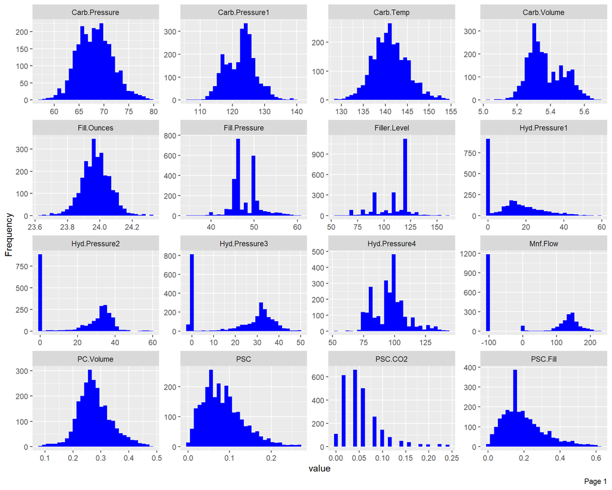

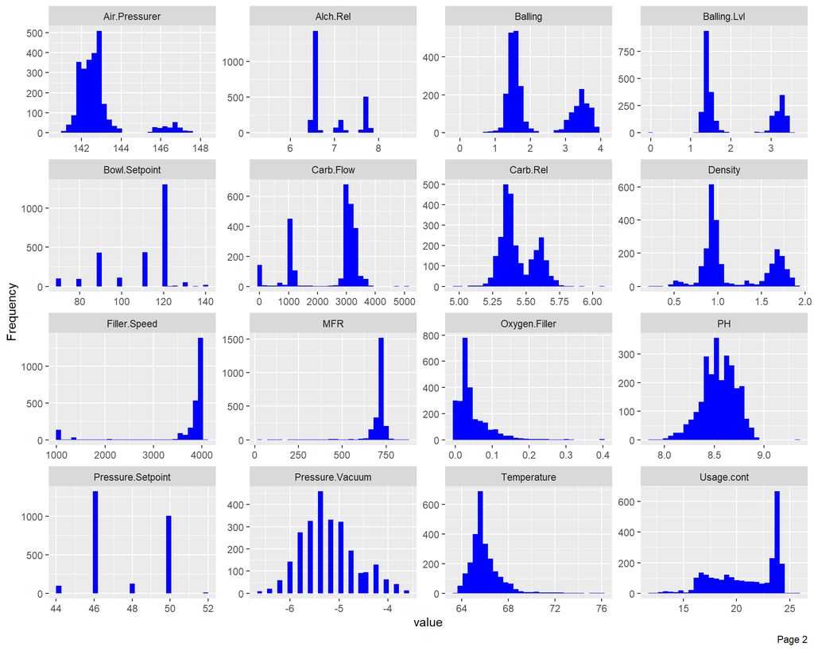

Log histograms:

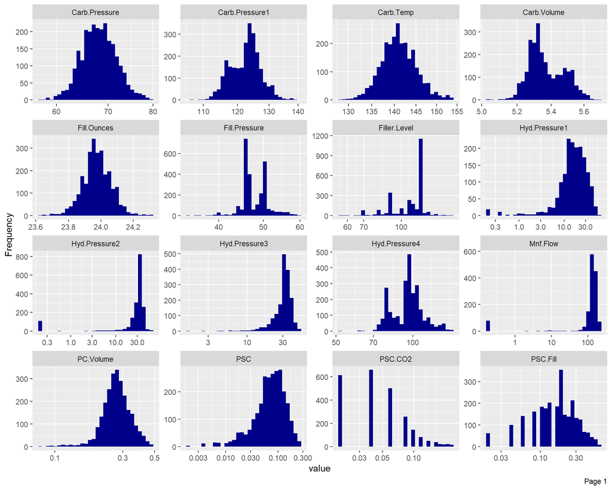

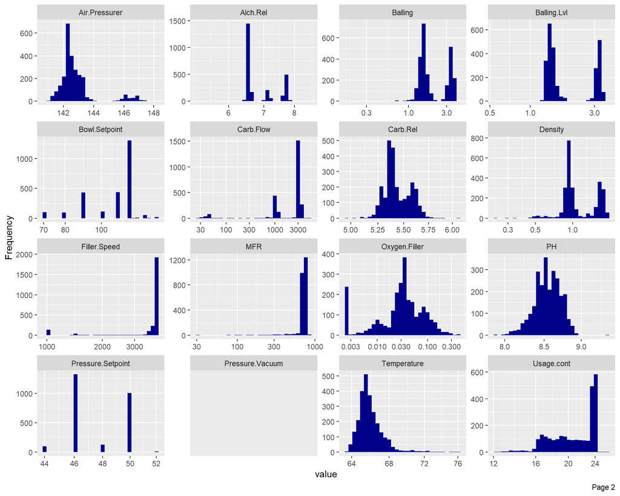

## Missing Data

Let’s review the missing data in the training set:

```
##        Brand Code       Carb Volume       Fill Ounces         PC Volume
##               120                10                38                39
##     Carb Pressure         Carb Temp               PSC          PSC Fill
##                27                26                33                23
##           PSC CO2          Mnf Flow    Carb Pressure1     Fill Pressure
##                39                 2                32                22
##     Hyd Pressure1     Hyd Pressure2     Hyd Pressure3     Hyd Pressure4
##                11                15                15                30
##      Filler Level      Filler Speed       Temperature        Usage cont
##                20                57                14                 5
##         Carb Flow           Density               MFR           Balling
##                 2                 1               212                 1
##   Pressure Vacuum                PH     Oxygen Filler     Bowl Setpoint
##                 0                 4                12                 2
## Pressure Setpoint     Air Pressurer          Alch Rel          Carb Rel
##                12                 0                 9                10
##       Balling Lvl
##                 1
```

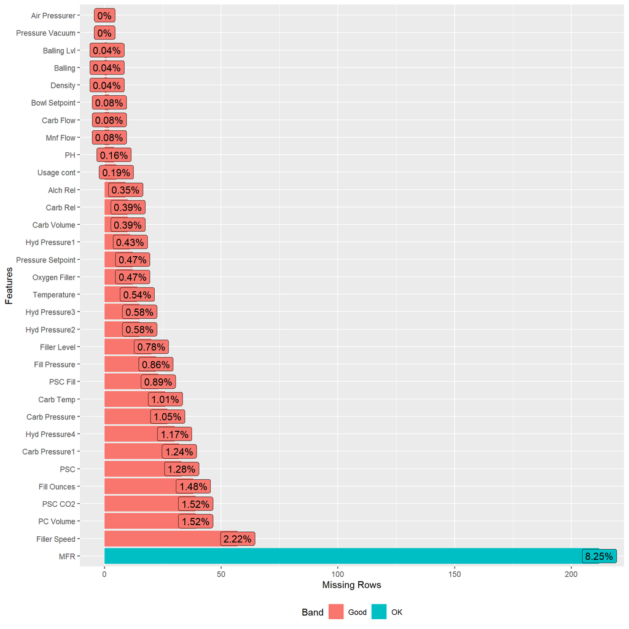

According to the graph, the variable that lacks data the most is the variable ‘MFR’, 8.25% of the data is missing. For the ‘filler speed’ variable, 2.22% of the data is missing. The missing data will be treated by imputation.

## Correlation

Let’s graph the correlation of the variables:

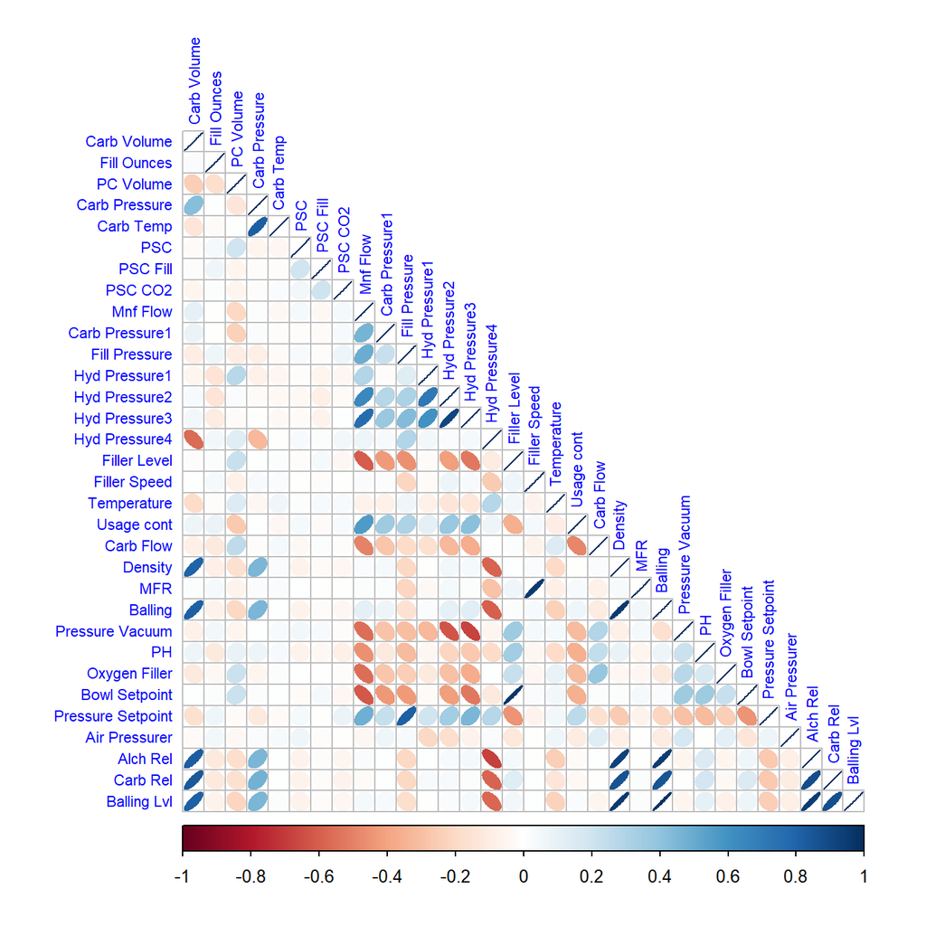

According to the graph we can see the correlation between the variables in the data set. We can see that a few variables are correlated. For data preparation, we will use pairwise predictors that have a correlation greater than 0.9.

## Outliers

Let’s use the Boxplot plots to check for outliers in the data set. Outliers could affect predictions. Let’s handle outliers using imputation.

Generating the Boxplot:

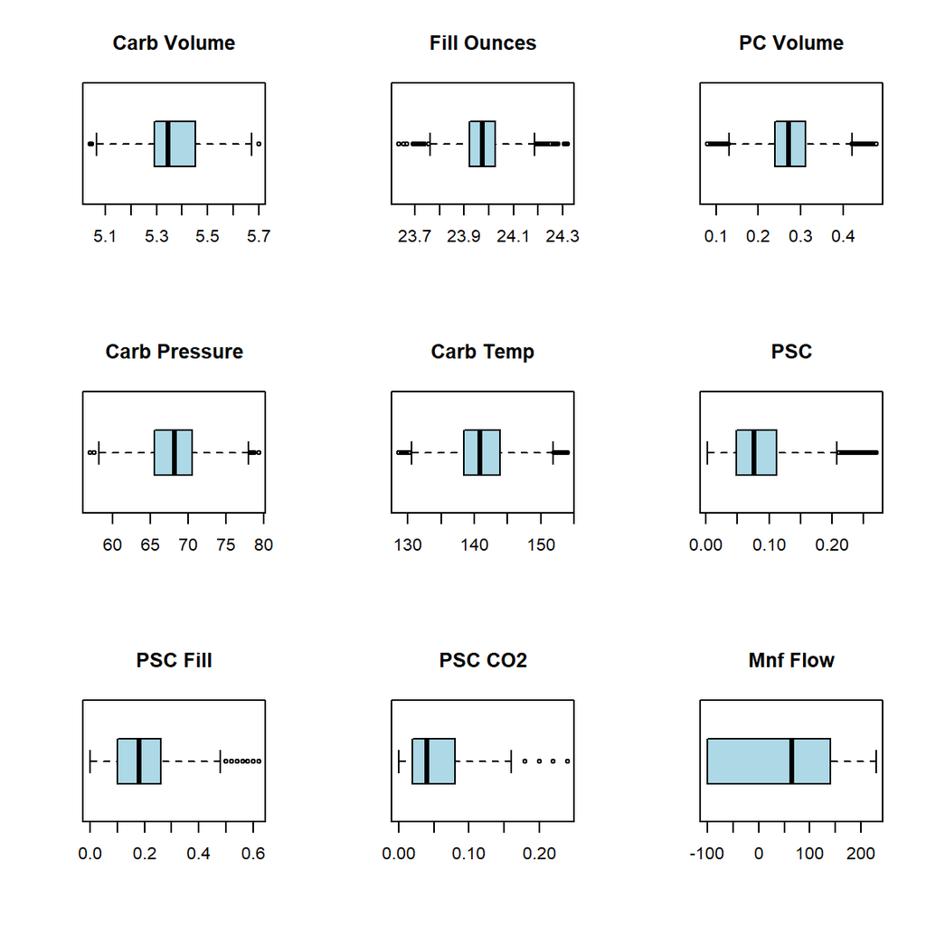

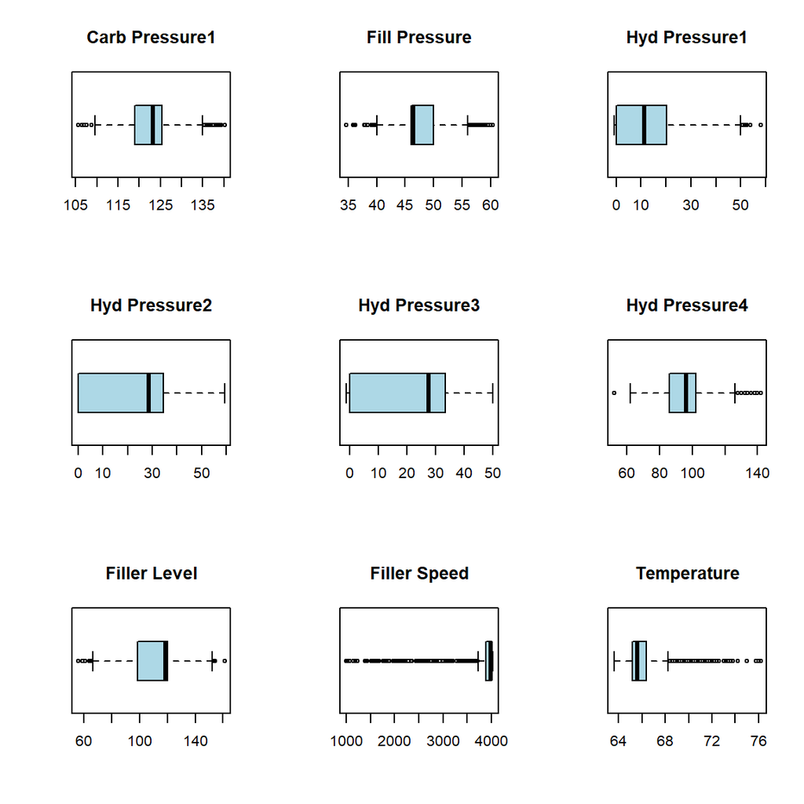

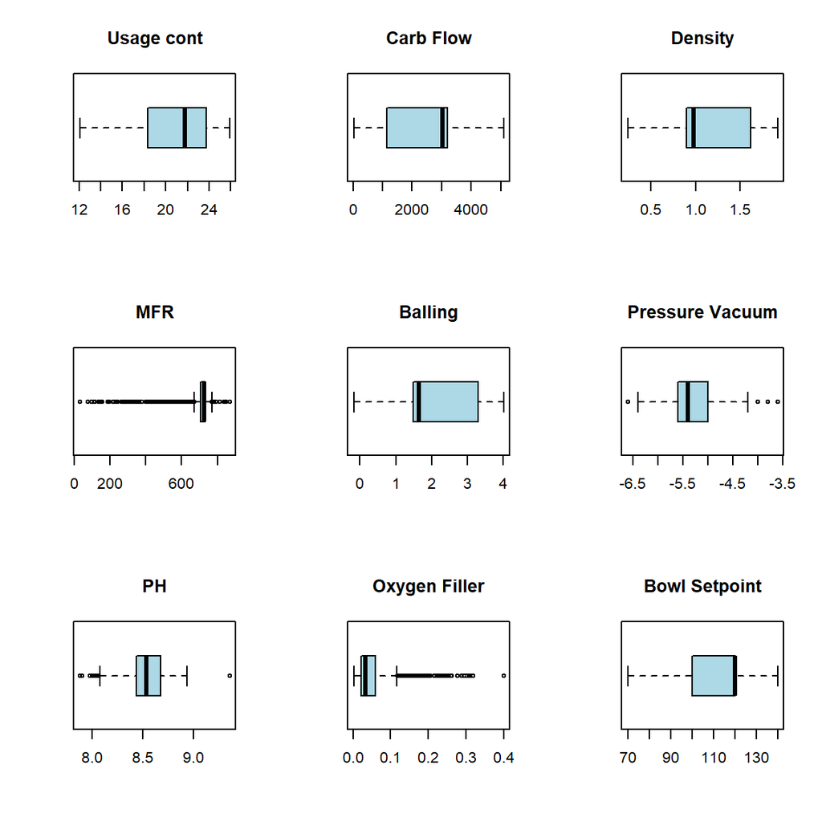

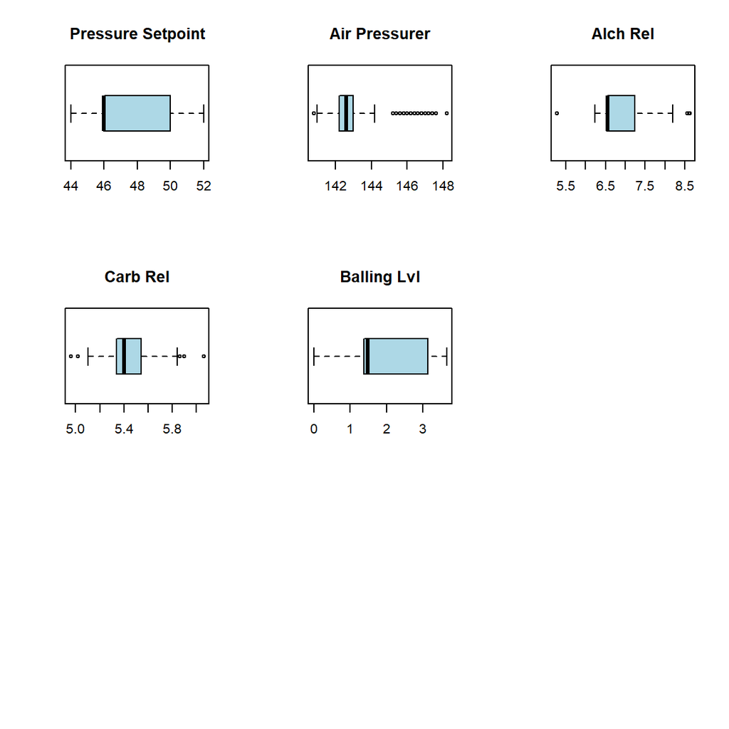

# Data Preparation

## Imputation

We will use the mice package to perform the imputation of missing data and outliers. Mice package is one of the most used packages, it creates multiple imputations for multivariate missing data. We are going to use ‘nearZeroVar’ to identify if a variable has no variation and is not useful for prediction. If we find any variable that is not useful for the prediction we will eliminate it.

Training set:

[output not shown]

[output cut: 15417 more lines]

Testing set:

[output not shown]

[output cut: 1593 more lines]

## Create Dummy Variables

Let’s use the ‘dummyVars’ function to create a full set of dummy variables, because the ‘Brandcode’ variable is a categorical variable that has 4 classes.

Training set:

Testing set:

## Correlation

We will use the pairwise predictors that have a correlation greater than 0.9.

## Transformation

Let’s use caret ‘preprocess’ method using transformation as ‘YeoJohnson’ which applies Yeo-Johnson transformation, like a BoxCox, and takes negative values into account.

## Training and Test Partition

Let’s partition the training dataset, for training and validation using ‘createDataPartition’ method from ‘caret’ package. We will use 75% of the data for training and 25% for validation.

Training/validation partition for independent variables and training/validation partition for dependent variable PH

# Build Models

## Linear Regression

### Simple Linear Regression

Let’s use Simple Linear Regression model, it will include all the predictor variables in training dataset.

```
##
## Call:
## lm(formula = y.train ~ ., data = X.train)
##
## Residuals:
##      Min       1Q   Median       3Q      Max
## -0.51293 -0.07915  0.00928  0.09202  0.79834
##
## Coefficients: (1 not defined because of singularities)
##                     Estimate Std. Error t value Pr(>|t|)
## (Intercept)       -4.515e+02  1.131e+03  -0.399 0.689665
## Brand.Code.A      -7.065e-02  1.820e-02  -3.883 0.000107 ***
## Brand.Code.B      -1.870e-03  2.826e-02  -0.066 0.947256
## Brand.Code.C      -1.257e-01  2.897e-02  -4.339 1.50e-05 ***
## Brand.Code.D              NA         NA      NA       NA
## Carb.Volume       -1.090e-01  7.859e-02  -1.387 0.165534
## Fill.Ounces       -2.132e-04  1.164e-04  -1.833 0.067025 .
## PC.Volume         -1.639e-01  1.006e-01  -1.629 0.103479
## Carb.Pressure      1.367e-01  7.317e-01   0.187 0.851863
## Carb.Temp          7.906e+02  1.959e+03   0.404 0.686584
## PSC               -5.765e-02  6.748e-02  -0.854 0.393004
## PSC.Fill          -8.232e-02  5.828e-02  -1.412 0.157985
## PSC.CO2           -9.129e-02  7.242e-02  -1.261 0.207626
## Mnf.Flow          -7.190e-04  5.455e-05 -13.180  < 2e-16 ***
## Carb.Pressure1     1.293e-02  1.489e-03   8.683  < 2e-16 ***
## Fill.Pressure      2.770e+00  9.150e-01   3.028 0.002498 **
## Hyd.Pressure2      6.787e-03  1.271e-03   5.338 1.05e-07 ***
## Hyd.Pressure4      1.031e-01  1.649e-01   0.625 0.532068
## Filler.Speed       1.616e-05  9.122e-06   1.771 0.076640 .
## Temperature       -1.248e-02  2.603e-03  -4.796 1.74e-06 ***
## Usage.cont        -6.924e-03  1.330e-03  -5.204 2.16e-07 ***
## Carb.Flow          8.275e-07  4.427e-07   1.869 0.061739 .
## MFR               -1.444e-04  5.455e-05  -2.648 0.008169 **
## Pressure.Vacuum   -3.982e-05  1.725e-04  -0.231 0.817490
## Oxygen.Filler     -3.580e-01  8.172e-02  -4.381 1.25e-05 ***
## Bowl.Setpoint      2.129e-03  3.075e-04   6.923 6.04e-12 ***
## Pressure.Setpoint -8.676e-03  2.298e-03  -3.775 0.000165 ***
## Air.Pressurer     -1.674e-04  2.748e-03  -0.061 0.951439
## Alch.Rel           4.078e-02  2.303e-02   1.771 0.076720 .
## Carb.Rel           1.115e-03  5.232e-02   0.021 0.983004
## ---
## Signif. codes:  0 '***' 0.001 '**' 0.01 '*' 0.05 '.' 0.1 ' ' 1
##
## Residual standard error: 0.1368 on 1901 degrees of freedom
## Multiple R-squared:  0.389,  Adjusted R-squared:   0.38
## F-statistic: 43.23 on 28 and 1901 DF,  p-value: < 2.2e-16
```

We can see that Simple Linear Regression model only covers 38% of variability of data.

### Tune PLS model

PLS model reduces the predictors to a smaller set of uncorrelated components and then performs least squares regression on these components, instead of on the original data. PLS finds linear combinations of the predictors called components.

```
## Partial Least Squares
##
## 1930 samples
##   29 predictor
##
## No pre-processing
## Resampling: Cross-Validated (10 fold)
## Summary of sample sizes: 1737, 1736, 1737, 1737, 1737, 1737, ...
## Resampling results across tuning parameters:
##
##   ncomp  RMSE       Rsquared    MAE
##    1     0.1714181  0.02717481  0.1372758
##    2     0.1700581  0.04443741  0.1364222
##    3     0.1551180  0.20411629  0.1219998
##    4     0.1544432  0.21072102  0.1216380
##    5     0.1538922  0.21608672  0.1213803
##    6     0.1530825  0.22418883  0.1209196
##    7     0.1525903  0.22932785  0.1206049
##    8     0.1457433  0.29744632  0.1134317
##    9     0.1439263  0.31464087  0.1120524
##   10     0.1426181  0.32730951  0.1109277
##
## Rsquared was used to select the optimal model using the largest value.
## The final value used for the model was ncomp = 10.
```

```
##    ncomp
## 10    10
```

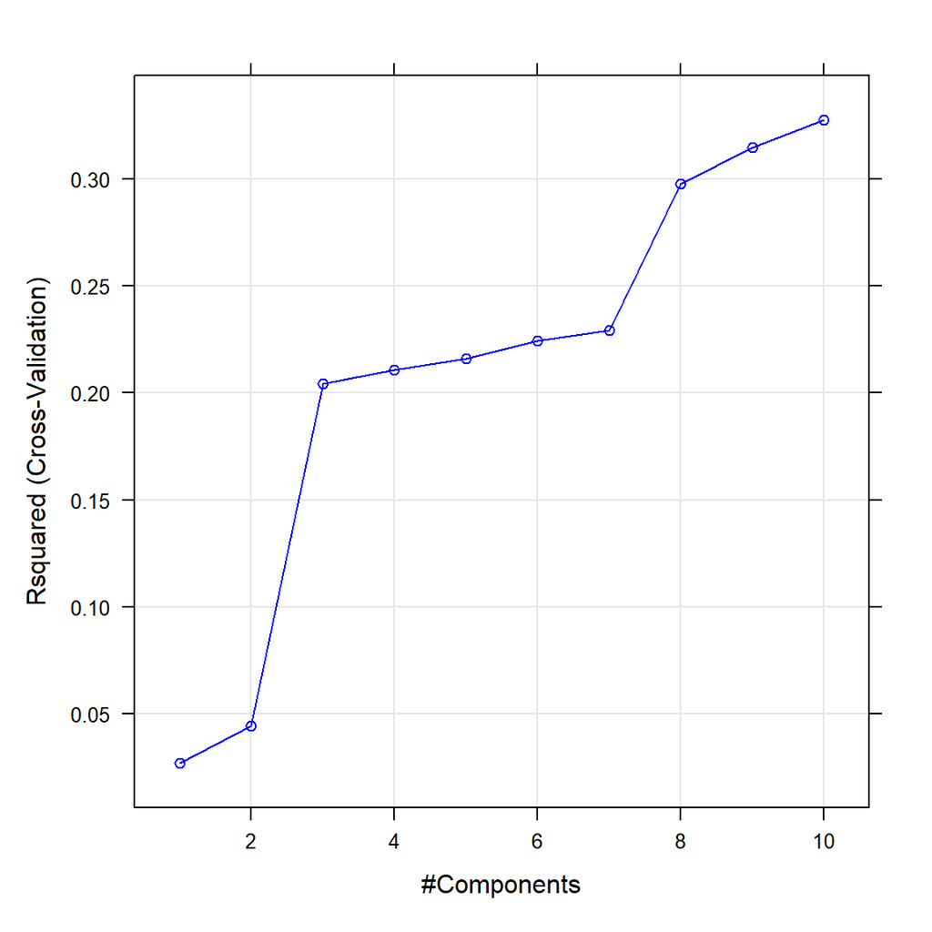

```
##   ncomp      RMSE  Rsquared
## 1    10 0.1426181 0.3273095
```

```
##    Rsquared      RMSE
## 1 0.3273095 0.1426181
```

The final value used for the model was ncomp = 10 which corresponds to best tune model. We see that R2 is 0.327 but it produces small RMSE.

## Non Linear Regression

### MARS

Let’s use MARS. MARS provide a convenient approach to capture the nonlinear relationships in the data by assessing cutpoints similar to step functions.

Final parameters:

```
##    nprune degree
## 54     26      2
```

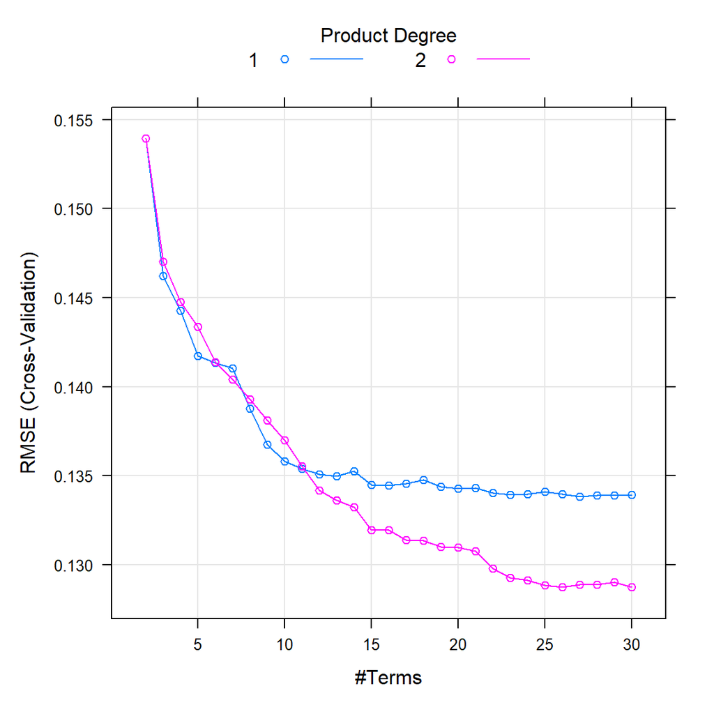

```
## Call: earth(x=data.frame[1930,29], y=c(8.36,8.94,8.2...), keepxy=TRUE,
##             degree=2, nprune=26)
##
##                                                     coefficients
## (Intercept)                                            8.3860015
## Brand.Code.C                                          -0.0714484
## h(0.199347-Mnf.Flow)                                   0.0017803
## h(74.8119-Carb.Pressure1)                             -0.0109588
## h(Carb.Pressure1-74.8119)                              0.0177480
## h(Alch.Rel-7.16)                                       0.1721412
## Brand.Code.C * h(0.189946-Hyd.Pressure2)              -0.8200266
## Brand.Code.C * h(65.4-Temperature)                    -0.2481461
## h(0.01-PSC) * h(Carb.Pressure1-74.8119)                4.9014455
## h(0.199347-Mnf.Flow) * h(Pressure.Vacuum- -78.7763)   -0.0000217
## h(0.199347-Mnf.Flow) * h(-78.7763-Pressure.Vacuum)    -0.0000251
## h(0.199347-Mnf.Flow) * h(Air.Pressurer-143.8)         -0.0003566
## h(Mnf.Flow-0.199347) * h(Air.Pressurer-143.2)          0.0003130
## h(Mnf.Flow-0.199347) * h(143.2-Air.Pressurer)         -0.0001864
## h(Carb.Pressure1-74.8119) * h(Usage.cont-21.78)       -0.0134513
## h(Carb.Pressure1-74.8119) * h(21.78-Usage.cont)       -0.0017854
## h(Carb.Pressure1-74.8119) * h(46-Pressure.Setpoint)    0.0096377
## h(69.2-Temperature) * h(0.17-Oxygen.Filler)            0.1434676
## h(90-Bowl.Setpoint) * h(7.16-Alch.Rel)                 0.0045778
## h(Bowl.Setpoint-90) * h(7.16-Alch.Rel)                 0.0058656
## h(7.16-Alch.Rel) * h(Carb.Rel-5.3)                    -0.5029443
##
## Selected 21 of 32 terms, and 14 of 29 predictors (nprune=26)
## Termination condition: RSq changed by less than 0.001 at 32 terms
## Importance: Mnf.Flow, Brand.Code.C, Bowl.Setpoint, Alch.Rel, Air.Pressurer, ...
## Number of terms at each degree of interaction: 1 5 15
## GCV 0.0158745    RSS 29.03998    GRSq 0.4743234    RSq 0.5012214
```

```
##    Rsquared      RMSE
## 1 0.4533862 0.1288859
```

### SVM

Let’s use SVM (Support Vector Machines). Using these support vectors, we do maximize the margin of the classifier.

```
## Support Vector Machines with Radial Basis Function Kernel
##
## 1930 samples
##   29 predictor
##
## No pre-processing
## Resampling: Cross-Validated (10 fold)
## Summary of sample sizes: 1736, 1738, 1737, 1738, 1737, 1737, ...
## Resampling results across tuning parameters:
##
##   C       RMSE       Rsquared   MAE
##     0.25  0.1291561  0.4581138  0.09582179
##     0.50  0.1263641  0.4779186  0.09272916
##     1.00  0.1252212  0.4858998  0.09130025
##     2.00  0.1250337  0.4878039  0.09111242
##     4.00  0.1249484  0.4909993  0.09144859
##     8.00  0.1263393  0.4840876  0.09288447
##    16.00  0.1285923  0.4735801  0.09517955
##    32.00  0.1334208  0.4521238  0.09942872
##    64.00  0.1390255  0.4290218  0.10398569
##   128.00  0.1455997  0.4032446  0.10927744
##
## Tuning parameter 'sigma' was held constant at a value of 0.02283882
## RMSE was used to select the optimal model using the smallest value.
## The final values used for the model were sigma = 0.02283882 and C = 4.
```

```
## Length  Class   Mode
##      1   ksvm     S4
```

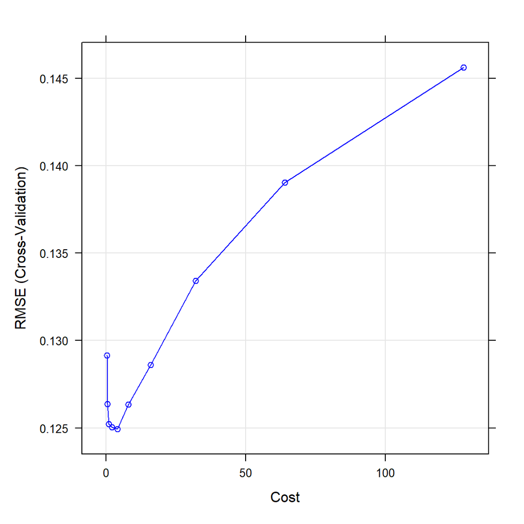

```
##    Rsquared      RMSE
## 1 0.4909993 0.1249484
```

RMSE was used to select the optimal model using the smallest value. The final values R2 value which is 0.49 but it also produces small RMSE.

## Trees

### Single Tree

Let’s use Regression trees. The regression trees partition a data set into smaller groups and then fit a simple model for each subgroup.

```
## CART
##
## 1930 samples
##   29 predictor
##
## No pre-processing
## Resampling: Cross-Validated (10 fold)
## Summary of sample sizes: 1736, 1737, 1737, 1736, 1737, 1737, ...
## Resampling results across tuning parameters:
##
##   cp          RMSE       Rsquared   MAE
##   0.01158064  0.1304195  0.4381087  0.09992524
##   0.01337602  0.1321422  0.4229168  0.10132008
##   0.01353857  0.1325389  0.4195737  0.10153900
##   0.01745528  0.1352964  0.3945305  0.10500203
##   0.01805078  0.1371042  0.3776956  0.10703389
##   0.02281590  0.1400504  0.3499953  0.11007571
##   0.03207331  0.1431617  0.3210315  0.11288772
##   0.04361386  0.1468192  0.2863758  0.11563940
##   0.05929179  0.1532795  0.2238780  0.12032696
##   0.21230067  0.1677856  0.1658403  0.13283913
##
## RMSE was used to select the optimal model using the smallest value.
## The final value used for the model was cp = 0.01158064.
```

```
##           cp
## 1 0.01158064
```

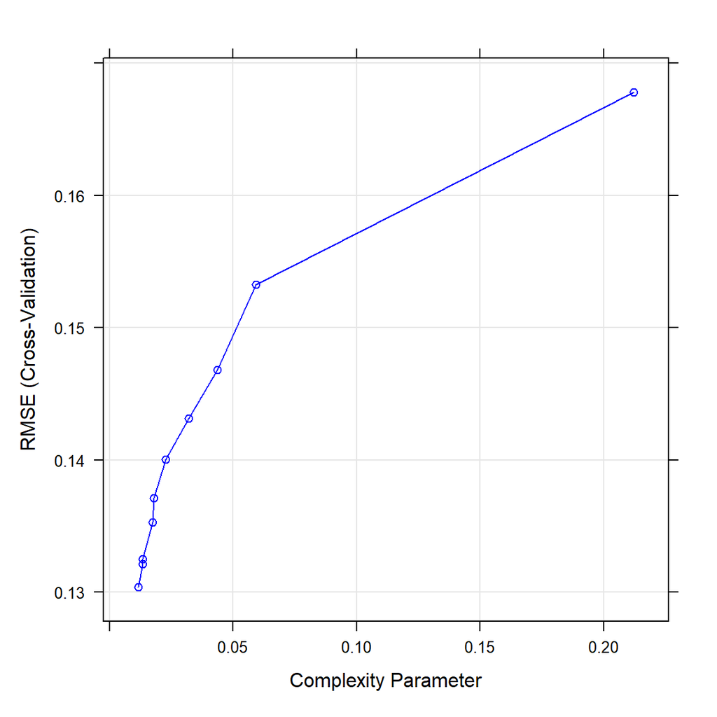

```
##    Rsquared      RMSE
## 1 0.4381087 0.1304195
```

RMSE was used to select the optimal model using the smallest value. The final value used for the model was cp = 0.01158064. We see R2 value is 0.438 and RMSE as 0.13.

### Boosted Tree

Boosting algorithm seeks to improve the prediction power by training a sequence of weak models where each of them compensates the weaknesses of its predecessors.

Boosting regression trees via stochastic gradient boosting machines:

```
## Stochastic Gradient Boosting
##
## 1930 samples
##   29 predictor
##
## No pre-processing
## Resampling: Cross-Validated (10 fold)
## Summary of sample sizes: 1738, 1736, 1737, 1737, 1738, 1737, ...
## Resampling results across tuning parameters:
##
##   interaction.depth  n.minobsinnode  n.trees  RMSE       Rsquared   MAE
##    5                  5              100      0.1188314  0.5367487  0.09089804
##    5                  5              200      0.1161751  0.5552666  0.08826392
##    5                  5              300      0.1157375  0.5587866  0.08789848
##    5                  5              400      0.1150955  0.5638123  0.08737017
##    5                  5              500      0.1146150  0.5677259  0.08678655
##    5                 10              100      0.1176615  0.5453004  0.09015795
##    5                 10              200      0.1155957  0.5590747  0.08783339
##    5                 10              300      0.1139327  0.5719722  0.08660097
##    5                 10              400      0.1139788  0.5720629  0.08671816
##    5                 10              500      0.1139347  0.5730236  0.08669917
##   10                  5              100      0.1125819  0.5827522  0.08509431
##   10                  5              200      0.1108144  0.5948769  0.08414518
##   10                  5              300      0.1104715  0.5975364  0.08353370
##   10                  5              400      0.1101379  0.6002912  0.08322626
##   10                  5              500      0.1100430  0.6013862  0.08306493
##   10                 10              100      0.1135209  0.5756605  0.08490594
##   10                 10              200      0.1131708  0.5775419  0.08433452
##   10                 10              300      0.1127381  0.5808554  0.08416279
##   10                 10              400      0.1127949  0.5807847  0.08394817
##   10                 10              500      0.1129422  0.5801136  0.08395629
##
## Tuning parameter 'shrinkage' was held constant at a value of 0.1
## RMSE was used to select the optimal model using the smallest value.
## The final values used for the model were n.trees = 500, interaction.depth =
##  10, shrinkage = 0.1 and n.minobsinnode = 5.
```

```
##    n.trees interaction.depth shrinkage n.minobsinnode
## 15     500                10       0.1              5
```

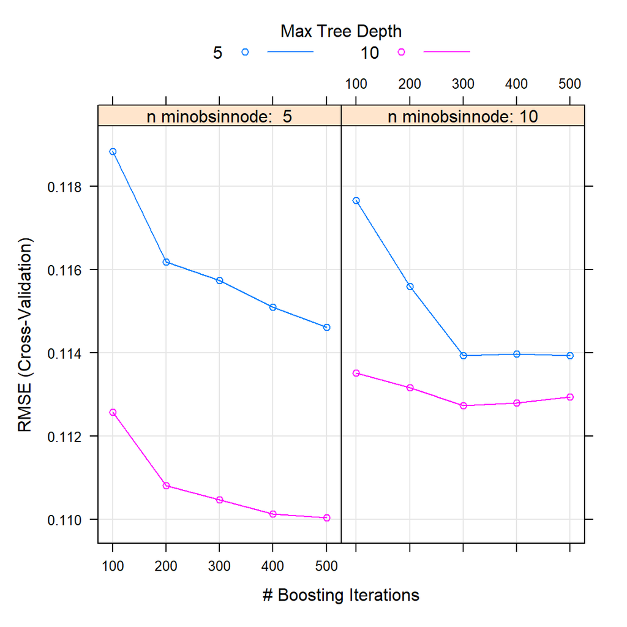

```
##    Rsquared      RMSE
## 1 0.6002912 0.1101379
```

Tuning parameter ‘shrinkage’ was held constant at a value of 0.1. RMSE was used to select the optimal model using the smallest value. The final values used for the model were n.trees = 500, interaction.depth is 10, shrinkage is 0.1 and n.minobsinnode is 5. The R2 is 0.6 and RMSE is 0.11 on training data.

### Random Forest

Random forest consists of a large number of individual decision trees that work as an ensemble. Each model in the ensemble is used to generate a prediction for a new sample and these predictions are then averaged to give the forest’s prediction.

```
## Random Forest
##
## 1930 samples
##   29 predictor
##
## No pre-processing
## Resampling: Cross-Validated (10 fold)
## Summary of sample sizes: 1736, 1737, 1737, 1738, 1737, 1737, ...
## Resampling results across tuning parameters:
##
##   mtry  RMSE       Rsquared   MAE
##    2    0.1165100  0.5981082  0.08910083
##    5    0.1073933  0.6477496  0.08075104
##    8    0.1049570  0.6563963  0.07831767
##   11    0.1036774  0.6609299  0.07679028
##   14    0.1029523  0.6627435  0.07595214
##   17    0.1021130  0.6668999  0.07507932
##   20    0.1020277  0.6657879  0.07483900
##   23    0.1018374  0.6659969  0.07457051
##   26    0.1018151  0.6641596  0.07418892
##   29    0.1019871  0.6616152  0.07411312
##
## RMSE was used to select the optimal model using the smallest value.
## The final value used for the model was mtry = 26.
```

```
##   mtry
## 9   26
```

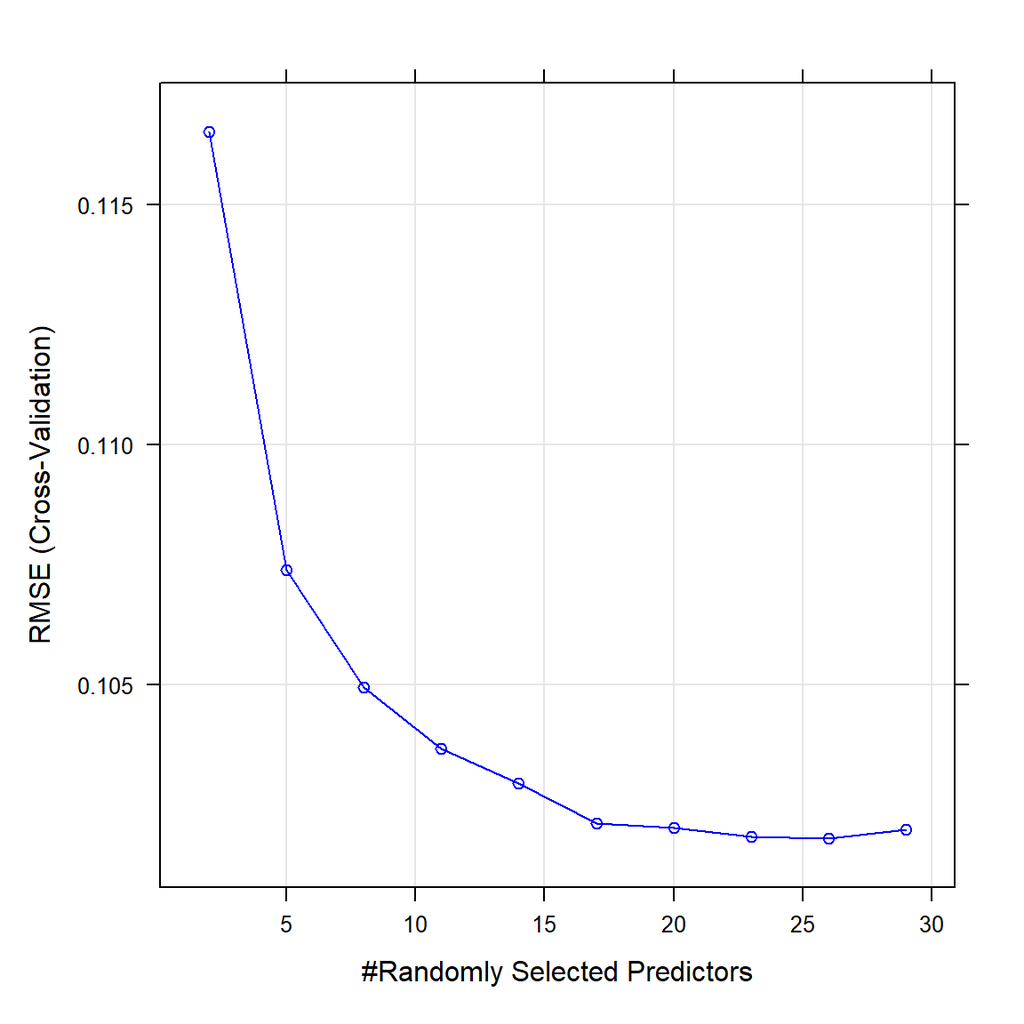

```
##    Rsquared      RMSE
## 1 0.6641596 0.1018151
```

RMSE was used to select the optimal model using the smallest value. The final value used for the model was mtry = 26. R2 is 0.66 and RMSE is 0.10.

Lets see the informative variables found by Random Forest models. we will use ‘varImp’ method to find these variables.

```
## rf variable importance
##
##   only 20 most important variables shown (out of 29)
##
##                 Overall
## Mnf.Flow        100.000
## Brand.Code.C     30.263
## Alch.Rel         26.398
## Oxygen.Filler    26.288
## Usage.cont       25.344
## Pressure.Vacuum  23.014
## Air.Pressurer    22.519
## Carb.Rel         19.792
## Carb.Pressure1   18.132
## Temperature      15.045
## Carb.Flow        11.741
## Filler.Speed     11.372
## Bowl.Setpoint    11.221
## PC.Volume        10.732
## Carb.Volume       8.054
## Fill.Pressure     7.896
## MFR               7.747
## Hyd.Pressure2     6.228
## Fill.Ounces       5.794
## PSC               5.772
```

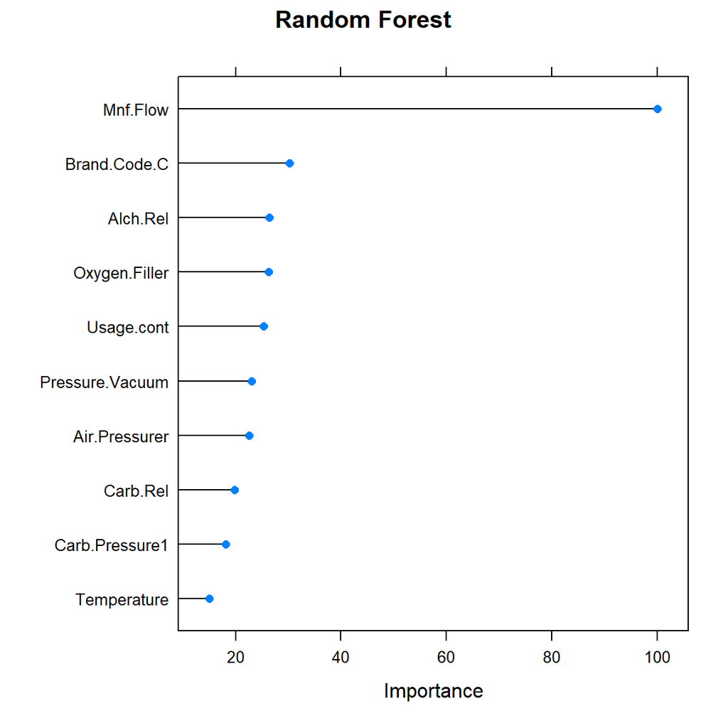

According to the graph, the most informative variable for the ‘PH’ response variable is ‘Mnf.Flow’.

### Cubist

Cubist is a rule-based model. A tree is built where the terminal leaves contain linear regression models. These models are based upon the predictors used in previous splits along with intermediate models.

```
## Cubist
##
## 1930 samples
##   29 predictor
##
## No pre-processing
## Resampling: Cross-Validated (10 fold)
## Summary of sample sizes: 1737, 1736, 1738, 1737, 1736, 1737, ...
## Resampling results across tuning parameters:
##
##   committees  neighbors  RMSE       Rsquared   MAE
##    1          0          0.1233367  0.5188322  0.08677618
##    1          5          0.1233367  0.5188322  0.08677618
##    1          9          0.1233367  0.5188322  0.08677618
##   10          0          0.1101702  0.6025717  0.08071610
##   10          5          0.1101702  0.6025717  0.08071610
##   10          9          0.1101702  0.6025717  0.08071610
##   20          0          0.1097309  0.6077717  0.08064492
##   20          5          0.1097309  0.6077717  0.08064492
##   20          9          0.1097309  0.6077717  0.08064492
##
## RMSE was used to select the optimal model using the smallest value.
## The final values used for the model were committees = 20 and neighbors = 0.
```

```
##   committees neighbors
## 7         20         0
```

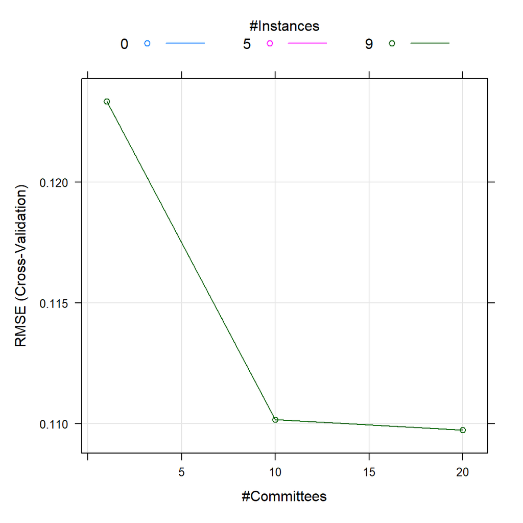

```
##    Rsquared      RMSE
## 1 0.6077717 0.1097309
```

RMSE was used to select the optimal model using the smallest value. The best tune for the cubist model which resulted in the smallest root mean squared error was with 20 committees. R2 is 0.6 and RMSE is 0.109.

### XGB Tree

[output not shown]

[output cut: 45 more lines]

[output not shown]

```
## eXtreme Gradient Boosting
##
## No pre-processing
## Resampling: Cross-Validated (5 fold)
## Summary of sample sizes: 1543, 1544, 1543, 1545, 1545
## Resampling results across tuning parameters:
##
##   max_depth  colsample_bytree  nrounds  RMSE       Rsquared   MAE
##   10         0.5                50      0.1254192  0.5715276  0.09742578
##   10         0.5               100      0.1112074  0.5935988  0.08132548
##   10         0.6                50      0.1234886  0.5827531  0.09590650
##   10         0.6               100      0.1101341  0.6001842  0.08107504
##   10         0.7                50      0.1215728  0.5967578  0.09426901
##   10         0.7               100      0.1087908  0.6098191  0.08005521
##   10         0.8                50      0.1231935  0.5846686  0.09470524
##   10         0.8               100      0.1100191  0.6003813  0.08023363
##   10         0.9                50      0.1207749  0.6021000  0.09272078
##   10         0.9               100      0.1085126  0.6126548  0.07915695
##   15         0.5                50      0.1266606  0.5693480  0.09855096
##   15         0.5               100      0.1121316  0.5861920  0.08234395
##   15         0.6                50      0.1255317  0.5782468  0.09663781
##   15         0.6               100      0.1112982  0.5926644  0.08065799
##   15         0.7                50      0.1255591  0.5814803  0.09744625
##   15         0.7               100      0.1114793  0.5914027  0.08135736
##   15         0.8                50      0.1255009  0.5765962  0.09658616
##   15         0.8               100      0.1122772  0.5856089  0.08174731
##   15         0.9                50      0.1254184  0.5782710  0.09608942
##   15         0.9               100      0.1118853  0.5883278  0.08038862
##   20         0.5                50      0.1256690  0.5803395  0.09796719
##   20         0.5               100      0.1110331  0.5946650  0.08221961
##   20         0.6                50      0.1246229  0.5871803  0.09663417
##   20         0.6               100      0.1107586  0.5964348  0.08110684
##   20         0.7                50      0.1253009  0.5803769  0.09690266
##   20         0.7               100      0.1118261  0.5881144  0.08149226
##   20         0.8                50      0.1236561  0.5901982  0.09465481
##   20         0.8               100      0.1101036  0.6003642  0.07958007
##   20         0.9                50      0.1249635  0.5892567  0.09643075
##   20         0.9               100      0.1111070  0.5950377  0.08025319
##   25         0.5                50      0.1261917  0.5778511  0.09820368
##   25         0.5               100      0.1114236  0.5925063  0.08213124
##   25         0.6                50      0.1269426  0.5683186  0.09828687
##   25         0.6               100      0.1124062  0.5838790  0.08190804
##   25         0.7                50      0.1239339  0.5896933  0.09610181
##   25         0.7               100      0.1100674  0.6008633  0.08019788
##   25         0.8                50      0.1256971  0.5792882  0.09715265
##   25         0.8               100      0.1122466  0.5862364  0.08186454
##   25         0.9                50      0.1267201  0.5734058  0.09668054
##   25         0.9               100      0.1128966  0.5821515  0.08085383
##
## Tuning parameter 'eta' was held constant at a value of 0.1
## Tuning
##  parameter 'min_child_weight' was held constant at a value of 1
##
## Tuning parameter 'subsample' was held constant at a value of 1
## RMSE was used to select the optimal model using the smallest value.
## The final values used for the model were nrounds = 100, max_depth = 10, eta
##  = 0.1, gamma = 0, colsample_bytree = 0.9, min_child_weight = 1 and subsample
##  = 1.
```

```
##    nrounds max_depth eta gamma colsample_bytree min_child_weight subsample
## 10     100        10 0.1     0              0.9                1         1
```

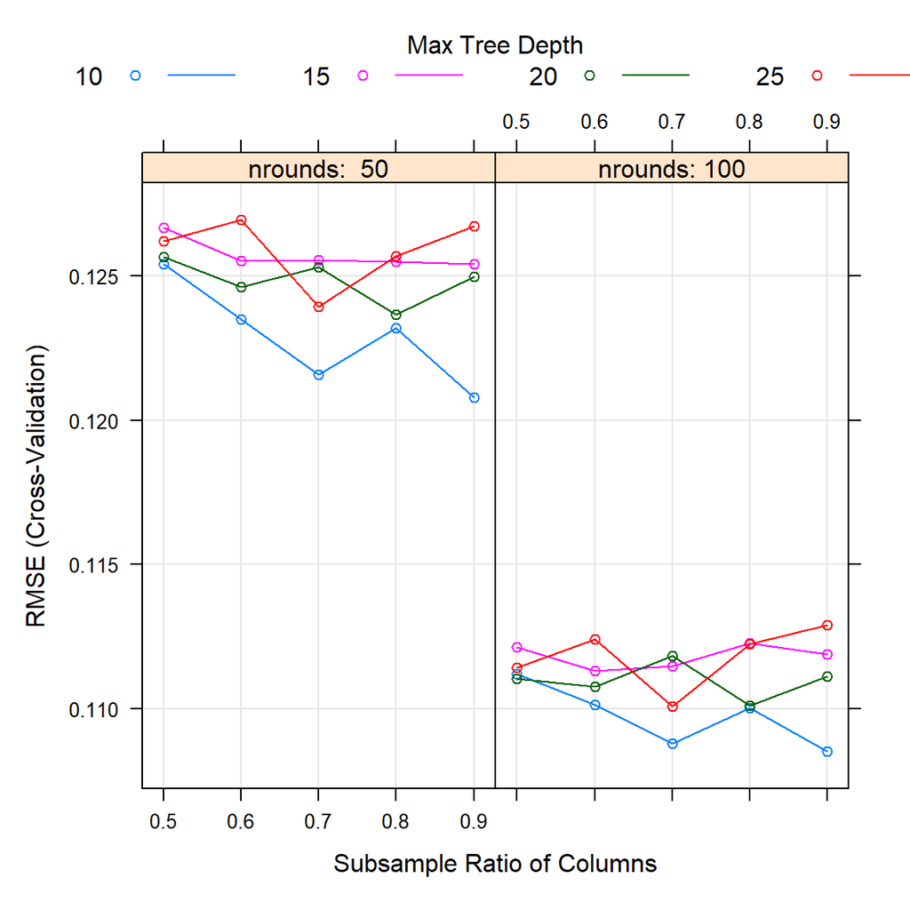

```
##   Rsquared      RMSE
## 1 0.578271 0.1254184
```

# Select Model

Let’s consider three parameters to select the best model to make the prediction:

R2, RMSE (Root Mean Squared Error), and MAE (Mean Absolute Error).

Let’s compare the previous values of the models made:

```
##
## Call:
## summary.resamples(object = resamples(list(PLS = pls_model, MARS =
##  mars_model, SVM = svm_model, RandFrst = rf_model, Cubist =
##  cubist_model, SingTree = st_model, Boosting = gbm_model)))
##
## Models: PLS, MARS, SVM, RandFrst, Cubist, SingTree, Boosting
## Number of resamples: 10
##
## MAE
##                Min.    1st Qu.     Median       Mean    3rd Qu.       Max. NA's
## PLS      0.09930614 0.10898453 0.10992366 0.11092766 0.11471496 0.12217176    0
## MARS     0.08948595 0.09146430 0.09576866 0.09779044 0.10139611 0.11196715    0
## SVM      0.08489957 0.08778646 0.09035997 0.09144859 0.09459460 0.10073926    0
## RandFrst 0.06160065 0.06876849 0.07412310 0.07418892 0.08016054 0.08500598    0
## Cubist   0.07385889 0.07800006 0.08023779 0.08064492 0.08321423 0.08938921    0
## SingTree 0.09312632 0.09589503 0.10006462 0.09992524 0.10342040 0.10831126    0
## Boosting 0.07041231 0.07773950 0.08435263 0.08306493 0.08601666 0.09545483    0
##
## RMSE
##                Min.    1st Qu.    Median      Mean   3rd Qu.      Max. NA's
## PLS      0.12507203 0.13892993 0.1409646 0.1426181 0.1503853 0.1569372    0
## MARS     0.11795947 0.11988593 0.1257406 0.1287331 0.1337033 0.1496115    0
## SVM      0.11152585 0.12040237 0.1264995 0.1249484 0.1287513 0.1356878    0
## RandFrst 0.08227912 0.09243682 0.1004166 0.1018151 0.1082739 0.1290152    0
## Cubist   0.10111991 0.10208894 0.1096399 0.1097309 0.1141616 0.1285880    0
## SingTree 0.11869981 0.12756459 0.1289066 0.1304195 0.1332688 0.1427214    0
## Boosting 0.09238569 0.10593250 0.1103785 0.1100430 0.1115190 0.1384106    0
##
## Rsquared
##               Min.   1st Qu.    Median      Mean   3rd Qu.      Max. NA's
## PLS      0.2441158 0.2827440 0.3382543 0.3273095 0.3564016 0.4294169    0
## MARS     0.3906945 0.4322607 0.4453613 0.4542486 0.4716526 0.5294308    0
## SVM      0.4170470 0.4673251 0.4860399 0.4909993 0.4971130 0.6008795    0
## RandFrst 0.5305131 0.6370911 0.6732938 0.6641596 0.7162991 0.7575908    0
## Cubist   0.4788001 0.6038862 0.6184220 0.6077717 0.6391279 0.6594011    0
## SingTree 0.3775980 0.4065106 0.4226986 0.4381087 0.4638068 0.5488421    0
## Boosting 0.5387655 0.5689732 0.5960815 0.6013862 0.6188955 0.6866308    0
```

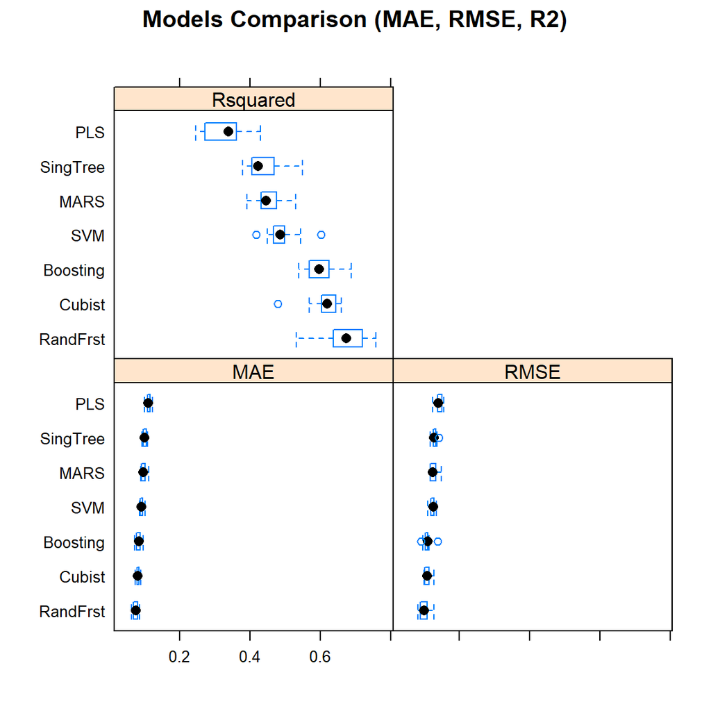

```
##                RMSE  Rsquared        MAE
## PLS      0.13312809 0.3784646 0.10362906
## MARS     0.12140644 0.4843683 0.09159462
## SVM      0.11365563 0.5515029 0.08572150
## SingTree 0.13024562 0.4076988 0.10094501
## RandFrst 0.09691869 0.6769197 0.07074728
## Boosting 0.10267793 0.6300082 0.07945764
## Cubist   0.10560226 0.6151575 0.07719413
```

Comparing all the models, we can see that the best model is ‘Random Forest’, according to the three chosen parameters.

# Prediction

Let’s use the most optimal model, which is the Random Forest model, to predict the PH values of the evaluation data set. Then we’ll write it to csv.

Remove PH from evaluation data for predict final PH values:

PH predictions for evaluation datase:

|  | value |
| --- | --- |
| 1 | 8.62123000000001 |
| 2 | 8.58917400000001 |
| 3 | 8.58770533333334 |
| 4 | 8.63052133333334 |
| 5 | 8.60057800000001 |
| 6 | 8.62483533333333 |
| 7 | 8.61271466666666 |
| 8 | 8.597796 |
| 9 | 8.59869933333333 |
| 10 | 8.62011066666667 |

[output cut: 257 more lines]

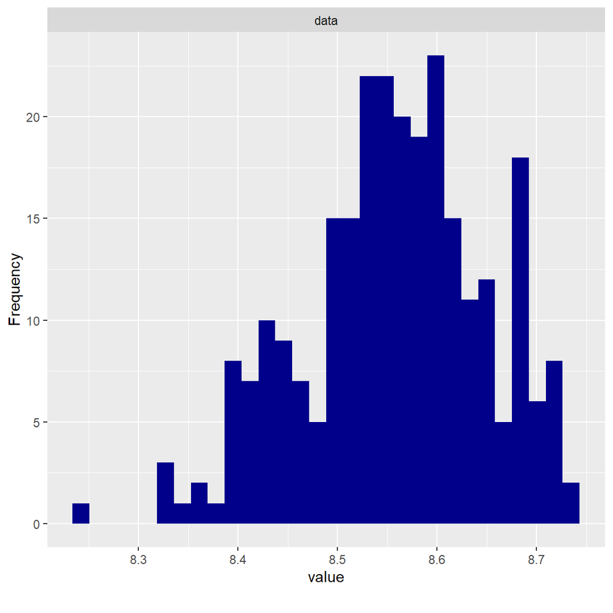

# Conclusion

We analyzed the data provided to us, first to determine missing data and outliers. We also perform a correlation between the variables. Then we’re going to modify outliers and missing values, create multiple imputations for multivariate missing data. We split the data into 75% and 25% for training and validation, respectively.

We use several models using linear regression, nonlinear regression and Trees model, to find the best model to make the predictions.

The optimal model established was Random Forest to predict PH values for the evaluation data, according to the chosen parameters of R2, RMSE and MAE.

According to the forecast, the predicted values are between 8 and 9, PH between 8 and 9.

We can say that the manufactured drink is alkaline. ABC Beverage Company mainly produces alkaline beverages such as tea, flavored waters, fruit juices.